# Bike Share Analysis

# Predicting Count of Total Rental Bikes Using KNN Regression

## “Authors: Cindy Jin, Linda Huang, Davis Li”

### Summary

We are going to build a regression model using the k-nearest neighbors algorithm. We will use three features: wind speed, normalized feeling temperature and season to predict the count of total rental bikes. This model could help the bike-sharing companies to better understand the distribution of the need for bikes and encourage people to support public transportation. Our current model has a prediction error, as measured by root mean squared error (RMSE), of about 1483. While we can improve the model given that the count of total rental bikes in our data set range from 22 to 8714, and the median count of total rental bikes is 4548, the model is still useful.

The data we used to build our model contains all the daily counts of rental bikes between years 2011 and 2012 in Capital bikeshare system. The data was collected from https://archive.ics.uci.edu/ml/datasets/Bike+Sharing+Dataset.

### Introduction

Bike sharing is a top-rated service. When people need to commute short distances, they can rent a car directly from the bike-sharing system at any time without buying a bike so that they can travel conveniently. While users can either register to be premium customers, they can also rent bikes casually. However, for this particular service, the problem we should pay the most attention to is the supply of rental bikes. What if there is a high demand on a particular day but the rental bikes are out of supply? What if the bike-sharing company prepares too many bikes but there is a supply surplus? Therefore, our question is can we use some important factors to predict the number of count of total rental bikes including both casual and registered for a particular day?

In an attempt to answer this question, we used a K-nearest neighbors regression model and data from daily counts of rental bikes between years 2011 and 2012 in Capital bikeshare system to build a regression model. We found that our regression model had a prediction error of about 1483. While we can improve the model given that the count of total rental bikes in our data set range from 22 to 8714, and the median count of total rental bikes is 4548, the model is still useful.

# Methods

### Data

The data set used in this project has totally 16 columns, including the daily counts of rental bikes collected during 2011 and 2012 in Capital bikeshare system from https://archive.ics.uci.edu/ml/datasets/Bike+Sharing+Dataset. Based on the correlation of each factor with the daily counts of rental bikes, we chose to focus on 3 predictor variables(Table 1).

| Predictor variable | Description |
| --- | --- |
| season | season (1:winter, 2:spring, 3:summer, 4:fall) |
| windspeed | Normalized wind speed. The values are divided to 67 (max) |
| atemp | Normalized feeling temperature in Celsius. The values are derived via (t-t_min)/(t_max-t_min), t_min=-16, t_max=+50 (only in hourly scale) |

The data set is already clean, with no missing values. So we only needed to remove the unused columns.

### Analysis

Using the R programming language and the tidymodels and tidyverse R packages, we carried out the analysis. The code used for the analysis is available in this paper, which was created using Jupyter.

### Result

```r
data <- read.csv("data/day.csv", header = T)|>     # read the data
        select(-instant, -dteday, -yr, -holiday, -casual, -registered)   # unselect some useless columns
head(data)
```

```
##   season mnth weekday workingday weathersit     temp    atemp      hum
## 1      1    1       6          0          2 0.344167 0.363625 0.805833
## 2      1    1       0          0          2 0.363478 0.353739 0.696087
## 3      1    1       1          1          1 0.196364 0.189405 0.437273
## 4      1    1       2          1          1 0.200000 0.212122 0.590435
## 5      1    1       3          1          1 0.226957 0.229270 0.436957
## 6      1    1       4          1          1 0.204348 0.233209 0.518261
##   windspeed  cnt
## 1 0.1604460  985
## 2 0.2485390  801
## 3 0.2483090 1349
## 4 0.1602960 1562
## 5 0.1869000 1600
## 6 0.0895652 1606
```

Finding the min and max range

```r
# find the range and median of the daily count
max <- max(data$cnt)
min <- min(data$cnt)
med <- median(data$cnt)
max
```

```
## [1] 8714
```

```r
min
```

```
## [1] 22
```

```r
med
```

```
## [1] 4548
```

Checking for missing values

```r
colSums(is.na(data))
```

```
##     season       mnth    weekday workingday weathersit       temp      atemp
##          0          0          0          0          0          0          0
##        hum  windspeed        cnt
##          0          0          0
```

Find correlations between all factors with daily count

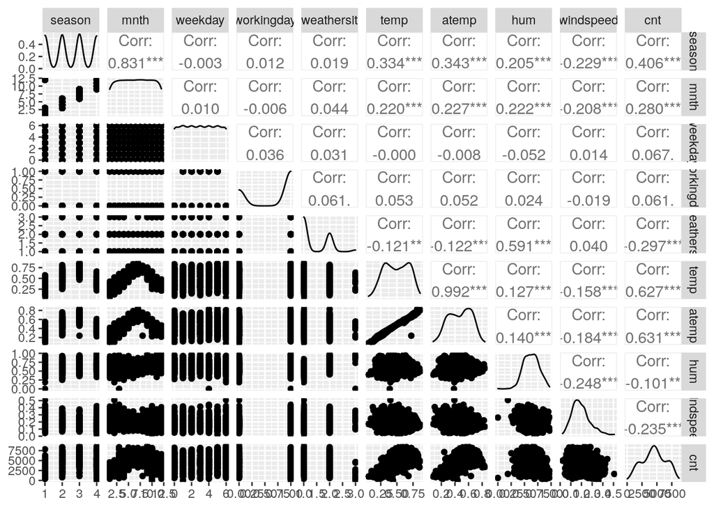

```r
options(repr.plot.width = 12, repr.plot.height = 12)
ggpairs(data)
```

Separate the data set into trainig set and test set

```r
training <- sample_n(data, nrow(data)*0.8, replace = FALSE)
testing <- anti_join(data, training)
```

[output not shown]

Select cnt as the target variable and windspeed&atemp&season as predictor variables, scale and center the predictor variables so that each variable is worth the same